# Writing SDA Queries that Return Geometry

2016-01-29  
Dylan Beaudette

## Introduction

This is a short tutorial on how to interact with the [Soil Data Access (SDA) web-service](http://sdmdataaccess.nrcs.usda.gov/) using R. Queries are written using a dialect of SQL. On first glance SQL appears similar to the language used to write NASIS queries and reports, however, these are two distinct languages. Soil Data Access is a "window" into the spatial and tabular data associated with the current SSURGO snapshot. Queries can contain spatial and tabular filters. If you are new to SDA or SQL, have a look at [this page](http://sdmdataaccess.nrcs.usda.gov/QueryHelp.aspx).

If this is your first time using SDA, please see a related [tutorial](https://r-forge.r-project.org/scm/viewvc.php/*checkout*/docs/soilDB/SDA-tutorial.html?root=aqp) to get started.

Additional tips on advanced spatial queries can be found [here](http://sdmdataaccess.sc.egov.usda.gov/documents/AdvancedSpatialDataAccess.pdf).

Follow along with the blocks of code below by copying / pasting into a new R "script" document. Each block of commands can be run by pasting them into the R console, or by "stepping through" lines of code by moving the cursor to the top of a block (in the R script panel) and repeatedly pressing ctrl + enter.

### Install Required R Packages

You only need to do this once. If you haven't installed these packages, then copy the code below and paste into the RStudio "console" pane.

```r
# run these commands in the R console
# stable version from CRAN + dependencies
install.packages("httr", dep=TRUE)
install.packages("soilDB", dep=TRUE)
install.packages("rgdal", dep = TRUE)
install.packages("raster", dep = TRUE)
install.packages("rgeos", dep = TRUE)
# latest versions from r-forge
install.packages("soilDB", repos = "http://R-Forge.R-project.org", type = "source")
```

### Simple Queries

Now that you have the required packages, load them into the current R session.

```r
library(soilDB)
library(rgeos)
library(sp)
library(maps)


# get polygons for a single mukey
q <- "SELECT G.MupolygonWktWgs84 as geom, '462594' as mukey from SDA_Get_MupolygonWktWgs84_from_Mukey('462594') as G"
res <- SDA_query(q)

# result is a data.frame, "MupolygonWktWgs84" contains WKT representation of geometry
str(res)
```

```
## 'data.frame':    38 obs. of  2 variables:
##  $ geom : chr  "POLYGON ((-120.77740109665115 37.628472182459824, -120.77724116990088 37.628467823952107, -120.77715902715808 37.62842004666634"| __truncated__ "POLYGON ((-120.87307467552661 37.62900777895004, -120.87300762026977 37.628995038704751, -120.87297861832062 37.628982297912977"| __trun…
##  $ mukey: int  462594 462594 462594 462594 462594 462594 462594 462594 462594 462594 ...
```

```r
# convert to SPDF
s <- processSDA_WKT(res)

# check
head(s@data)
```

| gid | mukey |
| --- | --- |
| 1 | 462594 |
| 2 | 462594 |
| 3 | 462594 |
| 4 | 462594 |
| 5 | 462594 |
| 6 | 462594 |

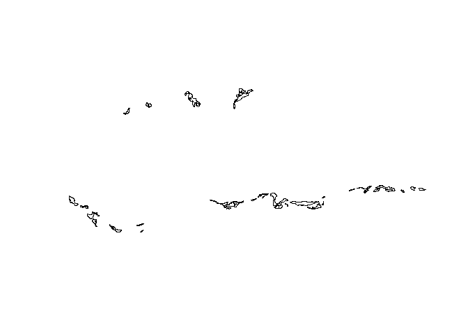

```r
plot(s)
```

```r
# get polygons associated with map units that contain "amador" as a major component
q <- "select G.MupolygonWktWgs84 as geom, mapunit.mukey, muname
FROM mapunit
CROSS APPLY SDA_Get_MupolygonWktWgs84_from_Mukey(mapunit.mukey) as G
WHERE mukey IN (SELECT DISTINCT mukey FROM component WHERE compname like 'amador%' AND majcompflag = 'Yes')"

res <- SDA_query(q)
str(res)
```

```
## 'data.frame':    262 obs. of  3 variables:
##  $ geom  : chr  "POLYGON ((-121.15252230315829 38.580559769164942, -121.15239322126237 38.5805240627318, -121.15232348375943 38.580526744993861,"| __truncated__ "POLYGON ((-121.05686027711923 38.461657600967762, -121.05679087490459 38.4616014427027, -121.05679053944492 38.461583337311417,"| __tru…
##  $ mukey : int  461845 461845 461845 461845 461845 461845 461845 461845 461845 461845 ...
##  $ muname: chr  "Amador-Gillender complex, 2 to 15 percent slopes" "Amador-Gillender complex, 2 to 15 percent slopes" "Amador-Gillender complex, 2 to 15 percent slopes" "Amador-Gillender complex, 2 to 15 percent slopes" ...
```

```r
s <- processSDA_WKT(res)

# check: OK
head(s@data)
```

| gid | mukey | muname |
| --- | --- | --- |
| 1 | 461845 | Amador-Gillender complex, 2 to 15 percent slopes |
| 2 | 461845 | Amador-Gillender complex, 2 to 15 percent slopes |
| 3 | 461845 | Amador-Gillender complex, 2 to 15 percent slopes |
| 4 | 461845 | Amador-Gillender complex, 2 to 15 percent slopes |
| 5 | 461845 | Amador-Gillender complex, 2 to 15 percent slopes |
| 6 | 461845 | Amador-Gillender complex, 2 to 15 percent slopes |

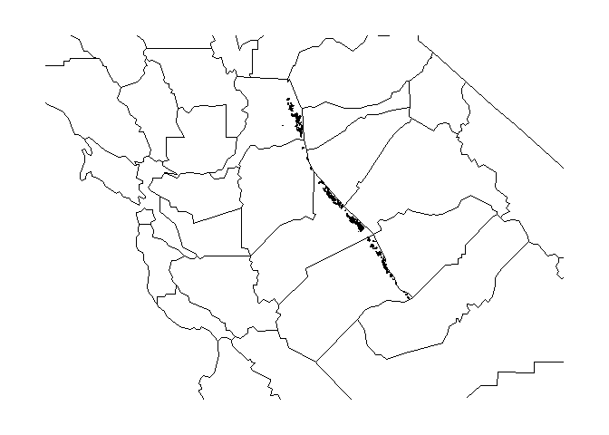

```r
# map
par(mar=c(0,0,0,0))
map('county', 'California', xlim=c(-123.25, -118.75), ylim=c(36.5, 39))
plot(s, add=TRUE)
```

This document is based on `soilDB` version 1.6.9.